# Notebook

A (DHT) Crawl Through The Altona Testnet 🕷

by [Jonny Rhea](https://twitter.com/JonnyRhea) of [TXRX Research](https://twitter.com/TXRXResearch)

Last Updated: 2020-07-17

🕸 Crawl Summary 🕸

- **Total number of nodes found:** 332

- **Number of nodes on Altona:** 109

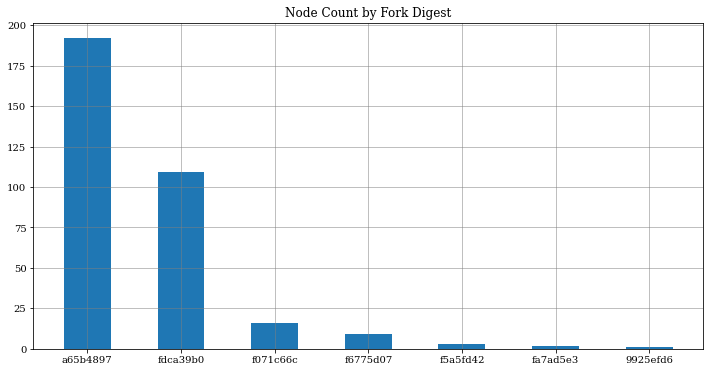

> Only nodes with fork-digest `fdca39b0` are members of the `Altona` network.

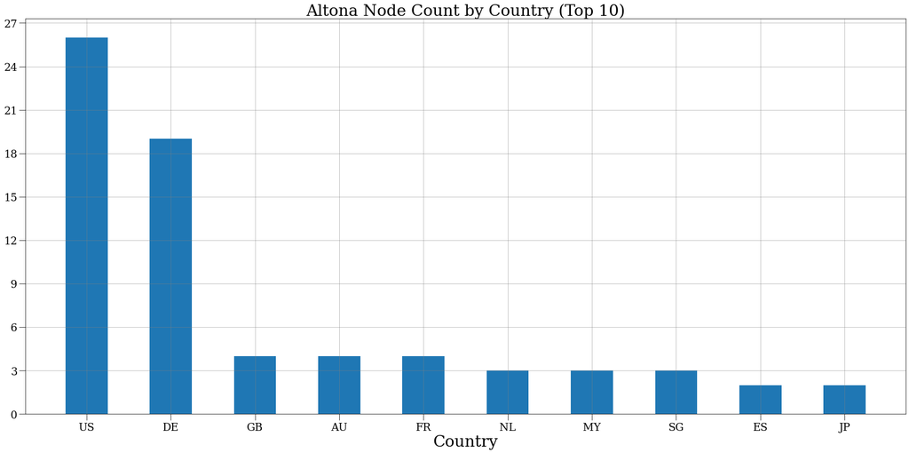

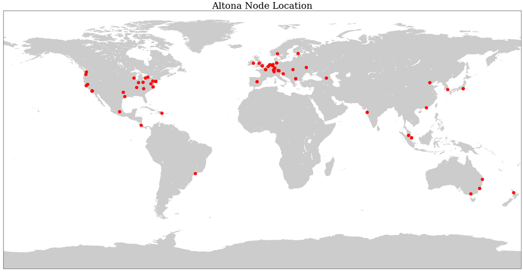

> Node location information is gathered by geolocating ip addresses 🌍

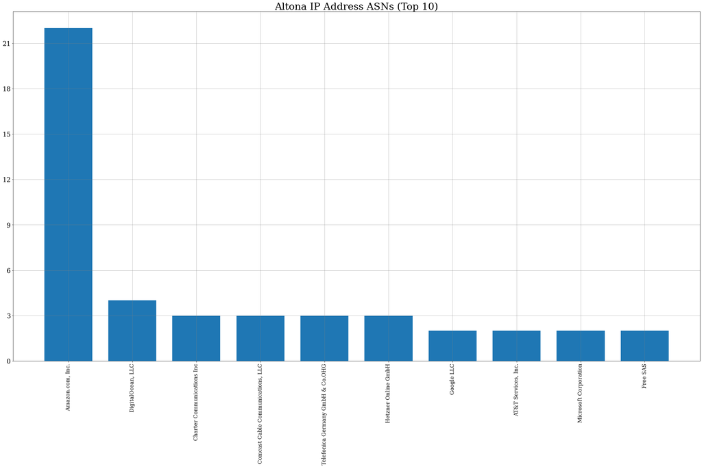

> This plot gives us an idea of the network's reliance on ISPs and cloud providers.

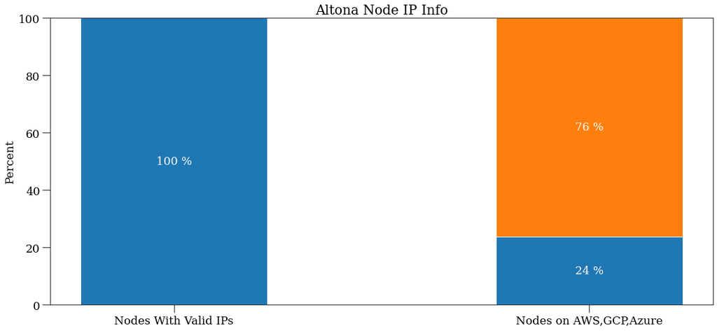

> - **Nodes with Valid IPs:** IP address within one of the private IPv4 network ranges were considered invalid.
> - **Nodes on AWS, GCP, Azure:** IP addresses that corresponded to an ASN that belongs to Amazon, Google, or Microsoft.

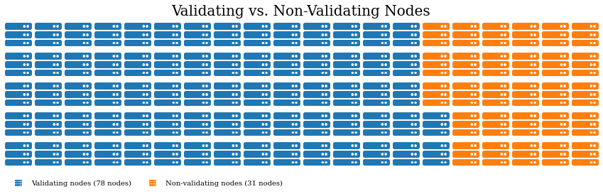

> If a node's ENR indicated that it belonged to one or more persistent committees, then it was considered a validating node.

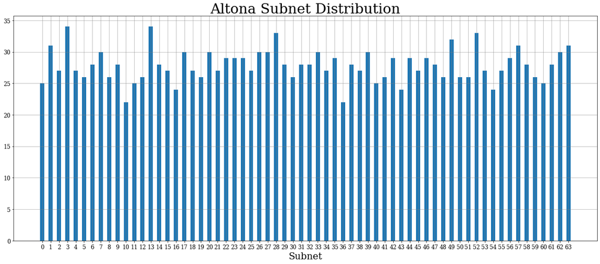

> Subnet subscriptions should be evenly distributed from `0 - 63`.

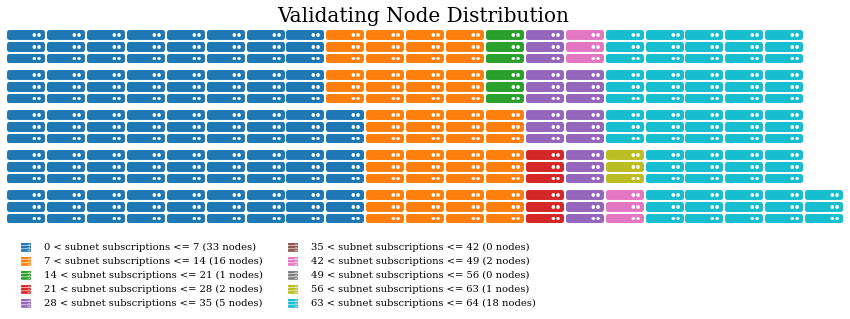

> This chart bucketizes nodes by the number of subnets they are subscribed to. This info can be used to estimate how many validators a particular node hosts. 😅

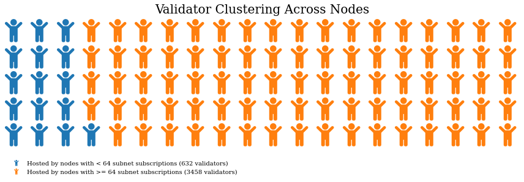

> Again, the subnet subscriptions are used to bucketize nodes. If a node has < 64 subnet subscriptions, then it is blue; otherwise, orange. A good rule of thumb to use when interpreting this chart is:
> - if you see a lot of blue, then validators probably fairly evenly spread across many nodes.
> - if you see a lot of orange, then most validators are probably hosted on just a few nodes.

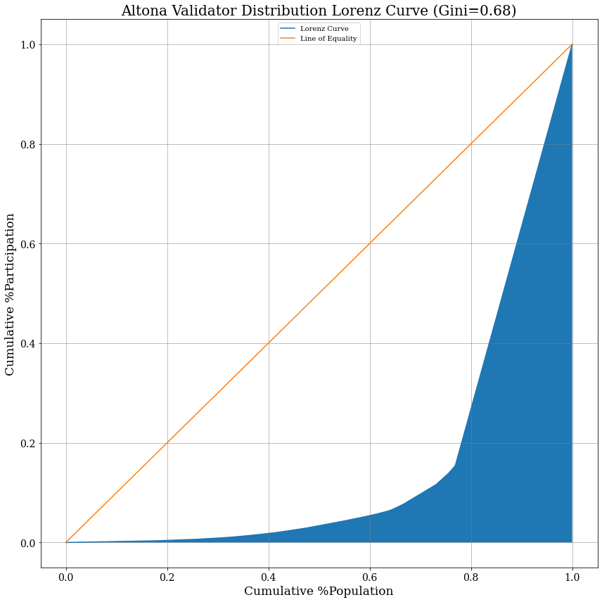

> The Gini coefficient and Lorenz Curve is another way to look at the distribution of validators across nodes. The closer the Gini coefficient is to zero, the more evenly distributed the validators are. Similarly, if every validating node hosted the same number of validators, then the shaded region would be the area under the 'Line of Equality' y=x.

```
Stored 'df_dht' (DataFrame)
```